# People_Analytics

**People Analytics:** Informal Networks

Python 3  
OCTO Technology - Clément Tailleur - People Analytics

**• Introduction**  
We have a .csv file 'data_processed.csv' containing the emails subjects of a company. Data are already cleaned.  
1. The goal of this notebook will be to detect natural topics in those emails.  
2. Then we will use this naturals topics to predict topic of each email.  
3. Finally we want to draw links between employees according to a specific topic in order to know informal networks of a company.

**• Summary**  
**I** - Data Cleaning  
**II** - Data Anonymization  
**III** - Detect natural topics: unsupervised learning  
**A** - Kmeans  
**B** - Dimensionality reduction / Visualization  
**C** - Get most similar words  
**IV** - Predict subjects topics: supervised learning  
**A** - Using labellized data  
**B** - Resolve variance with tags  
**C** - More robust model  
**V** - Graphical representation  
**A** - Group and filter interactions: example with 'technical' topic  
**B** - Visualizations et automations: example with 'technical' topic: display the n most numerous interactions interactions (n=500)

**I** - Data Cleaning  
In order to avoid an overload in this notebook, I decided to skip this part.  
You must know that we extracted addressees, senders and subjects. Then we cleaned subjects with specific text cleaning.  
• Special characters  
• Stopword  
• Stemming  
• Hapax  
Both of those steps were used in order to make the data_processed csv files.

**II** - Data Anonymization

```python
import pandas as pd
import numpy as np
from sklearn.feature_extraction.text import CountVectorizer

# We anonymize the senders and addressees names before displaying our dataframe
# Anonymize function is not displayed for more security

df_workable = pd.read_csv("../data/data_processed.csv", sep=",")
df_workable["Sender"] = df_workable["Sender"].apply(lambda x: anonymize(x))
df_workable["Addressee"] = df_workable["Addressee"].apply(lambda x: anonymize(x))

# Just take a look at our dataframe structure
df_workable[["Sender", "Addressee", "Year", "Subject", "Subject_Stem"]].head()
```

|  | Sender | Addressee | Year | Subject | Subject_Stem |
| --- | --- | --- | --- | --- | --- |
| 0 | mviem | digad | 2017 | Re: [Au 34] Fwd: Venez bouger votre corps à la... | venez bouger corp |
| 1 | mmonm | afaea | 2017 | Invitation: BAF Sanofi @ Mon Apr 24, 2017 4pm... | invitation baf sanofi alain faure |
| 2 | mmonm | mlaem | 2017 | Invitation: BAF Sanofi @ Mon Apr 24, 2017 4pm... | invitation baf sanofi alain faure |
| 3 | afaea | mmonm | 2017 | les 3 diagrammes | diagramme |
| 4 | mmonm | afaea | 2017 | Re: les 3 diagrammes | diagramme |

**III** - Detect natural topics: unsupervised learning  
**A** - Kmeans

```python
# Vectorization of "Subject_Stem" which is our clean data emails column
# We have to recover only unique emails
VEC = CountVectorizer()
X_unique = df_workable["Subject_Stem"].drop_duplicates(keep='first').reset_index(drop = True).tolist()
X_unique_counts = VEC.fit_transform(X_unique)

# From matrix Matrix to Dataframe
vocab = VEC.get_feature_names()
df_workable_Full_unique = pd.DataFrame(X_unique_counts.todense(),columns=vocab)
df_workable_Full_unique.head()
```

|  | _accor_plan | _air | _architecture | _baie | _benchmark_markeplaces_v | _bgl | _d | _draft_adept | _esi | _europcar | ... | zone | zoning | zont | zookeeper | zoom | zopa | zotto | zurich | zwn | zypper |
| --- | --- | --- | --- | --- | --- | --- | --- | --- | --- | --- | --- | --- | --- | --- | --- | --- | --- | --- | --- | --- | --- |
| 0 | 0 | 0 | 0 | 0 | 0 | 0 | 0 | 0 | 0 | 0 | ... | 0 | 0 | 0 | 0 | 0 | 0 | 0 | 0 | 0 | 0 |
| 1 | 0 | 0 | 0 | 0 | 0 | 0 | 0 | 0 | 0 | 0 | ... | 0 | 0 | 0 | 0 | 0 | 0 | 0 | 0 | 0 | 0 |
| 2 | 0 | 0 | 0 | 0 | 0 | 0 | 0 | 0 | 0 | 0 | ... | 0 | 0 | 0 | 0 | 0 | 0 | 0 | 0 | 0 | 0 |
| 3 | 0 | 0 | 0 | 0 | 0 | 0 | 0 | 0 | 0 | 0 | ... | 0 | 0 | 0 | 0 | 0 | 0 | 0 | 0 | 0 | 0 |
| 4 | 0 | 0 | 0 | 0 | 0 | 0 | 0 | 0 | 0 | 0 | ... | 0 | 0 | 0 | 0 | 0 | 0 | 0 | 0 | 0 | 0 |

5 rows × 15549 columns

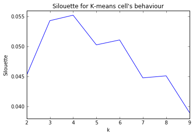

```python
# Silhouettes compute in order to obtain the optimum cluster number
from sklearn.metrics import silhouette_score
from sklearn.cluster import KMeans
import matplotlib.pyplot as plt
import pickle

# It's a very long computation so we registered our results in a txt file
def get_silhouette(max_cluster, vectorized_param, min_cluster = 0):
    s = []
    if max_cluster <= min_cluster:
        return None
    for n_clusters in range(min_cluster ,max_cluster):
        kmeans = KMeans(n_clusters=n_clusters)
        kmeans.fit(vectorized_param)
        labels = kmeans.labels_
        s.append(silhouette_score(vectorized_param, labels, metric='euclidean'))
    return s


def load_list(path):
    with open(path, "rb") as file:
        list_loaded = pickle.load(file)
    return list_loaded


min_cluster, max_cluster = 2, 10
#silhouettes = get_silhouette(min_cluster, max_cluster, X_unique_counts)
#save_list("../models/Kmeans/silhouettes.txt", silhouettes)
silhouettes = load_list("../models/Kmeans/silhouettes.txt")

plt.plot(range(min_cluster, max_cluster), silhouettes)
plt.ylabel("Silouette")
plt.xlabel("k")
plt.title("Silouette for K-means cell's behaviour")
plt.show()
```

```python
# We compute our algorithm using the best silhouette and save the model obtained
from sklearn.externals import joblib

silhouettes_dict = {}
for i, s in zip(range(min_cluster, max_cluster), range(len(silhouettes))):
    silhouettes_dict[silhouettes[s]] = i

num_clusters = silhouettes_dict[max(silhouettes)]
#km = KMeans(n_clusters=num_clusters).fit(X_unique_counts)
#joblib.dump(km, '../models/Kmeans/km_5_clusters.pkl')

km = joblib.load('../models/Kmeans/km_5_clusters.pkl')
clusters = km.labels_.tolist()
```

```python
# Now we can associate for each subject the cluster it belongs to.
mails = {'cluster': clusters, 'subject': X_unique}
frame = pd.DataFrame(mails, index = [clusters] , columns = ['subject', 'cluster'])
frame.head()
```

|  | subject | cluster |
| --- | --- | --- |
| 2 | venez bouger corp | 2 |
| 2 | invitation baf sanofi alain faure | 2 |
| 2 | diagramme | 2 |
| 2 | bof blockchain | 2 |
| 0 | mise jour diner octo acn | 0 |

```python
from __future__ import print_function

# In order to have an idea of natural topics, we display for each cluster the 15 most representative words.
# (centroid notion)
print("Top terms per cluster:")
print()
order_centroids = km.cluster_centers_.argsort()[:, ::-1]

for i in range(num_clusters):
    print("Number of subjects: %d"  % frame['cluster'][i].value_counts())
    print("Cluster %d words:" % i)

    for ind in order_centroids[i, :15]:
        print(vocab[ind], end=', ')
    print("\n\n")
#END FOR
```

```
Top terms per cluster:

Number of subjects: 5016
Cluster 0 words:
octo, people, bruit, invitation, question, corporate, audit, technology, tech, biz, proposition, fintech, presentation, formation, tr,


Number of subjects: 4980
Cluster 1 words:
people, bruit, tech, question, bof, bbl, usi, afh, biz, fierte, nouveau, corporate, nouvelle, presentation, google,


Number of subjects: 28282
Cluster 2 words:
invitation, question, biz, point, audit, mission, accepted, web, api, formation, manager, atelier, bbl, fintech, updated,


Number of subjects: 7294
Cluster 3 words:
tech, octo, question, afh, pg, java, web, bbl, biz, article, recherche, api, test, re, blog,
```

```python
# Thanks to the first clusters definition, we determined 3 topics
# 1. Technique | 2. Business-Management | 3. Corporate
# Number of subjects by cluster
frame['cluster'].value_counts()
```

```
2    28282
3     7294
0     5016
1     4980
Name: cluster, dtype: int64
```

**B** - Dimensionality reduction / Visualization

```python
import random

# In term of visualization we need to have only two dimensions.
# The compute is too long and too expensive for our computer so we decided to take a random sample of our data.
# We have to vectorized it and compute again the silhouette from this sample.
# Frome here we will make our dimensionality reduction
VEC_viz = CountVectorizer()
X_viz_unique = random.sample(X_unique, 2000) #sample size: 2000
X_viz_unique_counts = VEC_viz.fit_transform(X_viz_unique)
vocab_viz = VEC_viz.get_feature_names()
```

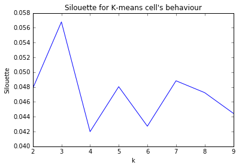

```python
silhouettes_viz = []
n_clusters = range(2,10)
for c in n_clusters:
    kmeans = KMeans(n_clusters=c)
    kmeans.fit(X_viz_unique_counts)

    labels = kmeans.labels_
    centroids = kmeans.cluster_centers_

    silhouettes_viz.append(silhouette_score(X_viz_unique_counts, labels, metric='euclidean'))

plt.close()
plt.plot(n_clusters, silhouettes_viz)
plt.ylabel("Silouette")
plt.xlabel("k")
plt.title("Silouette for K-means cell's behaviour")
plt.show()
```

```python
#clusters_viz
silhouettes_dict_viz = {}
for i, s in zip(range(min_cluster, max_cluster), range(len(silhouettes_viz))):
    silhouettes_dict_viz[silhouettes_viz[s]] = i

num_clusters_viz = silhouettes_dict_viz[max(silhouettes_viz)]
km_viz = KMeans(n_clusters=num_clusters_viz).fit(X_viz_unique_counts)
clusters_viz = km_viz.labels_.tolist()

#df_viz
mails_viz = { 'cluster': clusters_viz, 'subject': X_viz_unique}
frame_viz = pd.DataFrame(mails_viz, index = [clusters_viz] , columns = ['subject', 'cluster'])
```

```python
print("Top terms per cluster:")
print()
order_centroids_viz = km_viz.cluster_centers_.argsort()[:, ::-1]
clusters_viz_title = {}

for i in range(num_clusters_viz):
    print("Number of subjetcs: %d"  % frame_viz['cluster'][i].value_counts())
    print("Cluster %d words:" % i)

    clusters_viz_title[i] = []
    for ind in order_centroids_viz[i, :10]:
        clusters_viz_title[i].append(vocab_viz[ind])
        print(vocab_viz[ind], end=', ')
    print("\n\n")
#END FOR
```

```
Top terms per cluster:

Number of subjetcs: 327
Cluster 0 words:
tech, octo, question, afh, pg, java, article, biz, people, recherche,


Number of subjetcs: 1310
Cluster 1 words:
invitation, question, octo, biz, point, audit, mission, accepted, web, formation,


Number of subjetcs: 363
Cluster 2 words:
people, octo, bruit, question, corporate, nouveau, depart, usi, afh, bbl,
```

```python
from sklearn.metrics.pairwise import cosine_similarity
dist = 1 - cosine_similarity(X_viz_unique_counts)
```

```python
from sklearn.manifold import MDS

# Dimension reduction using distances
MDS()
mds = MDS(n_components=2, dissimilarity="precomputed", random_state=1)
pos = mds.fit_transform(dist)
xs, ys = pos[:, 0], pos[:, 1]
```

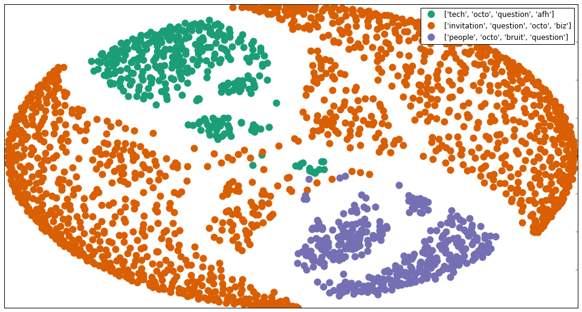

```python
def plot_cluster_viz(num_clusters_viz, xs, ys, clusters_viz, num_title_words, max_colors=5):
    if num_clusters_viz > max_colors:
        print("Please add cluster_colors parameters")
        return 0
    else:
        cluster_viz_colors = {}
        cluster_viz_names = {}
        for i in range(num_clusters_viz):
            cluster_viz_colors[i] = cluster_colors[i]
            cluster_viz_names[i] = clusters_viz_title[i][:num_title_words]

        df = pd.DataFrame(dict(x=xs, y=ys, label=clusters_viz))
        groups = df.groupby('label')
        fig, ax = plt.subplots(figsize=(17, 9))
        for name, group in groups:
            ax.plot(group.x, group.y, marker='o', linestyle='', ms=12, label=cluster_viz_names[name],
                    color=cluster_colors[name], mec='none')
            ax.set_aspect('auto')
            ax.tick_params(axis= 'x', which='both', bottom='off', top='off', labelbottom='off')
            ax.tick_params(axis= 'y', which='both', left='off', top='off', labelleft='off')
        ax.legend(numpoints=1)
        return plt

cluster_colors = {0: '#1b9e77', 1: '#d95f02', 2: '#7570b3', 3: '#e7298a', 4: '#66a61e'}
plt = plot_cluster_viz(num_clusters_viz, xs, ys, clusters_viz, num_title_words=4)
plt.show()
```

**C** - Get most similar words

```python
from gensim.models import Word2Vec,Phrases,Doc2Vec,TfidfModel

def F_mytokenizer(text):
    return text.split(' ')[1:]

num_features = 50 # dimension du vecteur
df_workable["Subject_Stem_token"] = df_workable["Subject_Stem"].apply(lambda x: F_mytokenizer(x))
model_SP = Word2Vec(df_workable["Subject_Stem_token"].values.tolist(),
                    min_count=1, workers=8, size=num_features, window=5)
```

```python
model_SP.most_similar("fhi", topn=5)
```

```
[('bbq', 0.7843244671821594),
 ('organisateur', 0.7634026408195496),
 ('barbec', 0.7126569747924805),
 ('barbecue', 0.7085720300674438),
 ('gaz', 0.7004834413528442)]
```

```python
model_SP.most_similar("bda", topn=5)
```

```
[('allocation', 0.4981083869934082),
 ('secu', 0.47929373383522034),
 ('traitement', 0.47792813181877136),
 ('mapr', 0.47742176055908203),
 ('bpm', 0.4768450856208801)]
```

```python
model_SP.most_similar("afh", topn=5)
```

```
[('surc', 0.5278175473213196),
 ('iso', 0.4975889325141907),
 ('predictif', 0.47981587052345276),
 ('capit', 0.47729361057281494),
 ('argument', 0.45895814895629883)]
```

**IV** - Predict subjects topics: supervised learning  
**A** - Using labellized data

```python
# We begin by recovering the subjetcs we labellized ourselves according to the 3 natural topics found with clustering.
df_tag = pd.read_csv('../data/data_filled_full_bilab.csv', sep=';')
print("Dataframe size:", len(df_tag))
df_tag = df_tag[df_tag.CLT_BILAB != -1]
print("Dataframe size workable:", len(df_tag))
print("Disagree after labellization: %.2f" % (1-np.mean(df_tag.CLT_BILAB==df_tag.AFA_BILAB)))
```

```
Dataframe size: 600
Dataframe size workable: 521
Disagree after labellization: 0.20
```

```python
from sklearn.feature_extraction.text import CountVectorizer
from sklearn.model_selection import cross_val_score
from sklearn.model_selection import ShuffleSplit
from sklearn.naive_bayes import MultinomialNB

# Vectorization of labellized data
X0 = df_tag["Subject_Stem"].tolist()
Y0 = df_tag["CLT_BILAB"].tolist()
VEC_0 = CountVectorizer()
X0_counts = VEC_0.fit_transform(X0)

# From Matrice to dataframe
vocab_0 = VEC_0.get_feature_names()
df_X0_counts = pd.DataFrame(X0_counts.todense(),columns=vocab_0)
df_X0_counts.head()
```

|  | aaron | abaques | abattu | abonnement | absent | academy | accenture | accepted | accepter | acces | ... | xamarin | xebia | xp | xxies | yde | yeh | your_favorite_paas | youssra | youtube | zone |
| --- | --- | --- | --- | --- | --- | --- | --- | --- | --- | --- | --- | --- | --- | --- | --- | --- | --- | --- | --- | --- | --- |
| 0 | 0 | 0 | 0 | 0 | 0 | 0 | 0 | 0 | 0 | 0 | ... | 0 | 0 | 0 | 0 | 0 | 0 | 0 | 0 | 0 | 0 |
| 1 | 0 | 0 | 0 | 0 | 0 | 0 | 0 | 0 | 0 | 0 | ... | 0 | 0 | 0 | 0 | 0 | 0 | 0 | 0 | 0 | 0 |
| 2 | 0 | 0 | 0 | 0 | 0 | 0 | 0 | 0 | 0 | 0 | ... | 0 | 0 | 0 | 0 | 0 | 0 | 0 | 0 | 0 | 0 |
| 3 | 0 | 0 | 0 | 0 | 0 | 0 | 0 | 0 | 0 | 0 | ... | 0 | 0 | 0 | 0 | 0 | 0 | 0 | 0 | 0 | 0 |
| 4 | 0 | 0 | 0 | 0 | 0 | 0 | 0 | 0 | 0 | 0 | ... | 0 | 0 | 0 | 0 | 0 | 0 | 0 | 0 | 0 | 0 |

5 rows × 1178 columns

```python
# Now we make a first learning with naive Baye. Algorithm which is very fast so convenient in order to have
# a first idea of our results
# Cross validation will divide our data set n_splits times in a train set and a test set.
# It will give us n_splits differents results. By dividing our data we ensure our results won't be specific to
# our train set. Doing it n_splits times and by taking the mean of our scores we increase
# our chances of having a stable score

clf_NB_0 = MultinomialNB()
cv = ShuffleSplit(n_splits=200, test_size=0.2, random_state=0)
scores = cross_val_score(clf_NB_0, X0_counts, Y0, cv=cv)
print("Mean score: %0.2f" % np.mean(scores))
print("Accuracy: %0.2f (+/- %0.2f)" % (scores.mean(), scores.std() * 2))
```

```
Mean score: 0.73
Accuracy: 0.73 (+/- 0.08)
```

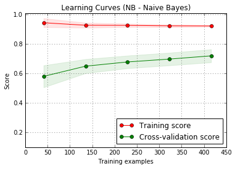

```python
from pylcurves import *

# For a first result, the score seems to be good. So we draw the learning curves
# Unfortunately, the gap between final scores of train and test is to big
# Meaning there is a problem of variance !
# We need more data to solve it.
title = "Learning Curves (NB - Naive Bayes)"
cv = ShuffleSplit(n_splits=50, test_size=0.2, random_state=0)
estimator = MultinomialNB()
plt = plot_learning_curves(estimator, title, X0_counts, Y0, ylim=(0.1, 1.01), cv=cv, n_jobs=4)
plt.show()
```

**B** - Resolve variance with tags

```python
from collections import Counter

def get_tag_used(column, n, s_left, s_right):
    subjects_list = []
    subjects = column.tolist()
    for s in subjects:
        s = s[s.find(s_left) + 1:s.find(s_right)]
        if s != "":
            subjects_list.append(s)
    key_words = Counter(subjects_list)
    return key_words.most_common(n)

# In order to have more data, our idea is to consider tags [] used by sender as labels
# Print Keywords tags
print(get_tag_used(df_workable["Subject"], 40, '[', ']'))
```

```
[('people', 264678), ('tech', 168430), ('octo-people', 26854), ('biz', 19814), ('au50', 6770), ('managers', 5692), ('octo-tech', 5564), ('princes-charmants', 4878), ('MSI', 4686), ('wp-gd-du-web', 4158), ('AFH', 3966), ('bfs', 3610), ('Au 34', 3450), ('JAVA', 3126), ('culture', 2624), ('ba', 2444), …
```

```python
import re

def keyword_modification(text, dict_transform):
    for key, value in dict_transform.items():
        text = re.sub(key, value, text)
    return text

# Divided keywords by topics identified before.
# Delete spaces
dic_all_tag = {"Managment": ["[biz]", "[managers]", "[BizWin]"],
           "Technical": ["[tech]", "[octo-tech]", "[JAVA]", "[BDA]", "[OPS]", "[PG]"],
           "Corporate": ["[corporate]", "[formation]", "[friends]", "[Cuisinedu1er]", "[askbob]", "[cofrance]",
                         "[Au34]", "[Recrutement]", "[au50]"]}
all_tag = [item for sublist in list(dic_all_tag.values()) for item in sublist]
tag_to_clean = {"Au 34": "Au34", "Cuisine du 1er": "Cuisinedu1er", "Biz Win": "BizWin"}
df_workable["Subject"] = df_workable["Subject"].apply(keyword_modification, args=(tag_to_clean,))
```

```python
def detect_tag(text, tag_list):
    for word in text.split():
        if word in tag_list:
            return 1
    return 0


def get_tag(df, all_tag):
    for k in all_tag.keys():
        column_dict = "Tag_" + str(k)
        if df[column_dict] == 1:
            return list(all_tag.keys()).index(k)
    return -1


def get_double_tag(df, col_topic_name, topic_tag):
    x = df[col_topic_name]
    topic_column = []
    for t in topic_tag:
        topic_column.append(str("Tag_" + t))
    for i in range(len(topic_tag)-1):
        if df[str(topic_column[i])] + df[str(topic_column[i+1])] == 2:
            return len(topic_tag) + i
    if df[str(topic_column[len(topic_tag)-1])] + df[str(topic_column[0])] == 2:
        return len(topic_tag)*2 - 1
    return x


def get_probs_tag(df_target, text_column, dic_all_tag):
    for k in dic_all_tag.keys():
        column_tag = "Tag_" + str(k)
        df_target[column_tag] = df_target[text_column].apply(detect_tag, args=(dic_all_tag[k],))
    df_target['Tag_Topic'] = df_target.apply(get_tag, args=(dic_all_tag,), axis=1)
    df_target['Tag_Topic'] = df_target.apply(get_double_tag, args=('Tag_Topic', list(dic_all_tag.keys())), axis=1)
    return df_target

# For the training we work only with unique subjects.
# Then we labellized subjects having keywords classified before.
# We delete mails we cannot labellized (without tag)
df_unique_workable = df_workable[["Subject", "Subject_Stem"]].drop_duplicates(subset="Subject_Stem", keep='first').reset_index(drop=True)
df_unique_workable = get_probs_tag(df_unique_workable, 'Subject', dic_all_tag)
df_learning = df_unique_workable[df_unique_workable['Tag_Topic'] != -1].copy()
df_learning.head()
```

|  | Subject | Subject_Stem | Tag_Managment | Tag_Technical | Tag_Corporate | Tag_Topic |
| --- | --- | --- | --- | --- | --- | --- |
| 0 | Re: [Au34] Fwd: Venez bouger votre corps à la ... | venez bouger corp | 0 | 0 | 1 | 2 |
| 8 | Re: [tech] File upload protection | tech file upload protection | 0 | 1 | 0 | 1 |
| 10 | Re: [tech] Re: [WTF-WITH-MOBILITY] Unicode et... | tech wtf mobility unicode java | 0 | 1 | 0 | 1 |
| 19 | [people] Re: [tech] Angular 2 & dynamic compo... | people tech angular dynamic component | 0 | 1 | 0 | 1 |
| 20 | Re: [tech] Angular 2 & dynamic component | tech angular dynamic component | 0 | 1 | 0 | 1 |

```python
# Vectoriez data again (more data now)
Ytarget1 = df_learning['Tag_Topic'].tolist()
X_learning1 = df_learning['Subject_Stem'].tolist()
VEC_learning1 = CountVectorizer()
X_learning1_counts = VEC_learning1.fit_transform(X_learning1)

# And new Naive Bayes classification
clf_NB_1 = MultinomialNB()
cv = ShuffleSplit(n_splits=200, test_size=0.2, random_state=0)
scores = cross_val_score(clf_NB_1, X_learning1_counts, Ytarget1, cv=cv)
print("Score moyen: %0.2f" % np.mean(scores))
print("Accuracy: %0.2f (+/- %0.2f)" % (scores.mean(), scores.std() * 2))
```

```
Score moyen: 0.95
Accuracy: 0.95 (+/- 0.01)
```

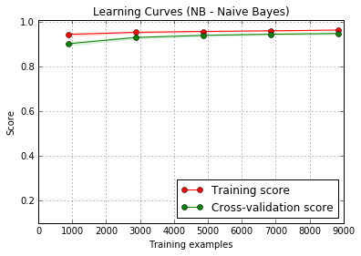

```python
# Great results but almost weird.
# We analyse learning curves. It seems too easy.
# Probably because of keywords which distort the model
title = "Learning Curves (NB - Naive Bayes)"
cv = ShuffleSplit(n_splits=50, test_size=0.2, random_state=0)
estimator = MultinomialNB()
plt.close()
plt = plot_learning_curves(estimator, title, X_learning1_counts, Ytarget1, ylim=(0.1, 1.01), cv=cv, n_jobs=4)
plt.show()
```

**C** - More robust model

```python
# In order to have a model more robust, we decide to delete the keywords of subjects we used to labellized mails.
def remove_keyword(text, keywords):
    keyword_cleaned = ""
    for word in text.split():
        if not word in keywords:
            keyword_cleaned =  keyword_cleaned + " " + word
    return keyword_cleaned

df_learning["Subject_Without_Keyword"] = df_learning["Subject"].apply(remove_keyword, args=(all_tag,))
```

```python
import unicodedata

def clean_spec_char(text):
    text_clean = re.sub("-", " ", text)
    text_clean = text_clean.replace("?", " question ")
    text_clean = re.sub(r'[\w\.-]+@[\w\.-]+', ' ', text_clean)
    text_clean = re.sub("[^\w\d'\s]+", " ", text_clean)
    text_clean = re.sub(" CA ", " conseiladministration ", text_clean)
    text_clean = text_clean.lower()
    text_clean = re.sub(r"[a-z][']", " ", text_clean)
    text_clean = re.sub("'", " ", text_clean)
    text_clean = re.sub("ça", "cela", text_clean)
    text_clean = (unicodedata.normalize('NFKD', text_clean).encode('ascii', 'ignore')).decode("utf-8")
    # clean Version_1.1
    text_clean = re.sub("bis", " ", text_clean)
    text_clean = re.sub("devis", "expertise", text_clean)
    text_clean = re.sub("au revoir", "bye ", text_clean)
    # clean Version 2.0
    text_clean = re.sub(" o3 ", " oneonone ", text_clean)
    text_clean = re.sub("\d+", " ", text_clean)
    text_clean = re.sub(" pm ", "", text_clean)
    text_clean = re.sub(" am ", "", text_clean)
    return text_clean


def clean_from_spec_list(text, words_list):
    text_cleaned = ""
    for word in text.split():
        if word not in words_list:
            text_cleaned =  text_cleaned + " " + word
    return text_cleaned


def get_stopwords(path, separator):
    with open(path, "r") as f:
        stopwords = f.read()
    stopwords_tokens = stopwords.split(separator)
    return stopwords_tokens


def get_mail_stopwords():

    stopwords_fr = get_stopwords("../data_cleaning/stopwords_fr.txt", "\n")
    stopwords_en = get_stopwords("../data_cleaning/stopwords_en.txt", "\n")
    stopwords_mail = ['re', 'fwd', 'lundi', 'mardi', 'mercredi', 'jeudi', 'vendredi', 'samedi', 'dimanche',
                      'janvier', 'fevrier', 'mars', 'avril', 'mai', 'juin', 'juillet', 'aout', 'septembre',
                      'octobre', 'decembre', 'jan', 'feb', 'mar', 'apr', 'jun', 'jul', 'aug', 'sep', 'oct',
                      'nov', 'dec', 'mon', 'tue', 'wed', 'thu', 'fri', 'sat', 'sun', 'am', 'pm']
    stopwords_mail.extend(stopwords_fr)
    stopwords_mail.extend(stopwords_en)
    return stopwords_mail


def load_list(path):
    with open(path, "rb") as file:
        list_loaded = pickle.load(file)
    return list_loaded


def clean_text(text, stopwords, hapax):
    text_cleaned = clean_spec_char(text)
    text_cleaned = clean_from_spec_list(text_cleaned, stopwords)
    text_cleaned = clean_from_spec_list(text_cleaned, hapax)
    text_cleaned = clean_plural(text_cleaned)
    return text_cleaned


def clean_plural(text):
    text_plural_cleaned = ""
    for word in text.split():
        word = word.rstrip('s')
        word = word.rstrip('x')
        text_plural_cleaned = text_plural_cleaned + " " + word
    return text_plural_cleaned

# We have to clean again data using functions defined previously (not in the notebook)
stopwords_mail = get_mail_stopwords()
hapax = load_list("../data_cleaning/hapax.txt")
df_learning["Subject_Without_Keyword_Stem"] = df_learning["Subject_Without_Keyword"].apply(clean_text, args=(stopwords_mail,hapax))
df_learning.head()
```

|  | Subject | Subject_Stem | Tag_Managment | Tag_Technical | Tag_Corporate | Tag_Topic | Subject_Without_Keyword | Subject_Without_Keyword_Stem |
| --- | --- | --- | --- | --- | --- | --- | --- | --- |
| 0 | Re: [Au34] Fwd: Venez bouger votre corps à la ... | venez bouger corp | 0 | 0 | 1 | 2 | Re: Fwd: Venez bouger votre corps à la Zumb | venez bouger corp |
| 8 | Re: [tech] File upload protection | tech file upload protection | 0 | 1 | 0 | 1 | Re: File upload protection | file upload protection |
| 10 | Re: [tech] Re: [WTF-WITH-MOBILITY] Unicode et... | tech wtf mobility unicode java | 0 | 1 | 0 | 1 | Re: Re: [WTF-WITH-MOBILITY] Unicode et java | wtf mobility unicode java |
| 19 | [people] Re: [tech] Angular 2 & dynamic compo... | people tech angular dynamic component | 0 | 1 | 0 | 1 | [people] Re: Angular 2 & dynamic component | people angular dynamic component |
| 20 | Re: [tech] Angular 2 & dynamic component | tech angular dynamic component | 0 | 1 | 0 | 1 | Re: Angular 2 & dynamic component | angular dynamic component |

```python
# New data = new vectorization !
Ytarget2 = df_learning['Tag_Topic'].tolist()
X_learning2 = df_learning['Subject_Without_Keyword'].tolist()
VEC_learning2 = CountVectorizer()
X_learning2_counts = VEC_learning2.fit_transform(X_learning2)

# New NB classification. Score lower but more robust car it is not depending of keywords used
clf_NB_2 = MultinomialNB()
cv = ShuffleSplit(n_splits=200, test_size=0.2, random_state=0)
scores = cross_val_score(clf_NB_2, X_learning2_counts, Ytarget2, cv=cv)
print("Score moyen: %0.2f" % np.mean(scores))
print("Accuracy: %0.2f (+/- %0.2f)" % (scores.mean(), scores.std() * 2))
```

```
Score moyen: 0.81
Accuracy: 0.81 (+/- 0.01)
```

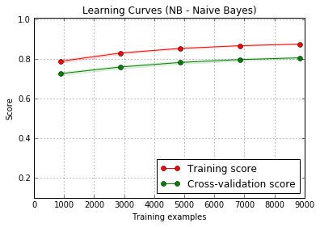

```python
# Learning curves more classical
title = "Learning Curves (NB - Naive Bayes)"
cv = ShuffleSplit(n_splits=50, test_size=0.2, random_state=0)
estimator = MultinomialNB()
plt.close()
plt = plot_learning_curves(estimator, title, X_learning2_counts, Ytarget2, ylim=(0.1, 1.01), cv=cv, n_jobs=4)
plt.show()
```

```python
from sklearn import svm

# SVM: Should be better than NB because it is not based on features independance !
# SVM: with default parameters, not as good as NB but optimizable !

X_learning2_counts = VEC_learning2.fit_transform(X_learning2)
X02_clean_counts = VEC_learning2.transform(X0)
clf_SMV = svm.SVC()
cv = ShuffleSplit(n_splits=50, test_size=0.2, random_state=0)
scores = cross_val_score(clf_SMV, X_learning2_counts, Ytarget2, cv=cv)
print("Mean score: %0.2f" % np.mean(scores))
print("Accuracy: %0.2f (+/- %0.2f)" % (scores.mean(), scores.std() * 2))
```

```
Mean score: 0.69
Accuracy: 0.69 (+/- 0.02)
```

```python
from sklearn.model_selection import GridSearchCV

# Use GridSearch in order to find best parameters
parameters = {'kernel':('linear', 'rbf'), 'C':[1,2,3,4,5,6,7,8,9,10],
              'gamma': [0.01,0.02,0.03,0.04,0.05]}
#clf_SMV_ALL = svm.SVC()
#grid = GridSearchCV(clf_SMV_ALL, parameters)
#grid = grid.fit(X_learning2_counts, Ytarget2)
#joblib.dump(grid.best_params_, '../models/SVM/best_parameters.pkl')
best_params = joblib.load('../models/SVM/best_parameters.pkl')

c = best_params["C"]
kernel = best_params["kernel"]
gamma = best_params["gamma"]
print("C:", c, "\nKernel:", kernel, "\nGamma:", gamma)
```

```
C: 4
Kernel: rbf
Gamma: 0.04
```

```python
all_topics = list(dic_all_tag.keys())
for i in range(len(all_topics)-1):
    all_topics.append(str(all_topics[i]+"-"+all_topics[i+1]))
all_topics.append(str(all_topics[len(list(dic_all_tag.keys()))-1]+"-"+all_topics[0]))

print(np.unique(Y0))
print(all_topics)
```

```
[0 1 2 3 4 5]
['Managment', 'Technical', 'Corporate', 'Managment-Technical', 'Technical-Corporate', 'Corporate-Managment']
```

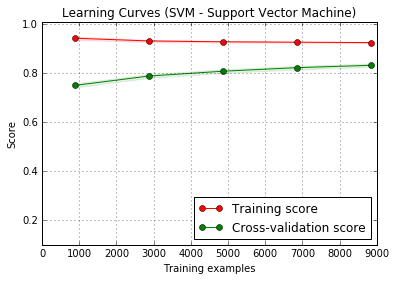

```python
# We reduce gap. We have better score and without use sender tags
title = "Learning Curves (SVM - Support Vector Machine)"
cv = ShuffleSplit(n_splits=50, test_size=0.2, random_state=0)
estimator = svm.SVC(C=c, kernel=kernel, gamma=gamma)
plt.close()
plt = plot_learning_curves(estimator, title, X_learning2_counts, Ytarget2, ylim=(0.1, 1.01), cv=cv, n_jobs=4)
plt.show()
```

```python
from sklearn import metrics

# Skewed classes need specific metrics
X_learning2_counts = VEC_learning2.fit_transform(X_learning2)
clf_BEST_SVM = svm.SVC(C=c, kernel=kernel, gamma=gamma)
clf_BEST_SVM = clf_BEST_SVM.fit(X_learning2_counts, Ytarget2)
predicted_X2_svm = clf_BEST_SVM.predict(X_learning2_counts)

print(metrics.classification_report(Ytarget2, predicted_X2_svm,
                                    target_names=all_topics))
```

```
                     precision    recall  f1-score   support

          Managment       0.93      0.83      0.88      1967
          Technical       0.92      0.99      0.95      7630
          Corporate       0.97      0.82      0.89      1141
Managment-Technical       0.84      0.29      0.43       247
Technical-Corporate       0.90      0.27      0.42        33
Corporate-Managment       1.00      0.37      0.54        35

        avg / total       0.92      0.92      0.92     11053
```

```python
my_hapax = load_list("../data_cleaning/hapax.txt")
my_hapax.append("bonjour")

my_test = ["[biz] Bonjour, Audit de perform", "[people] bye bye octo :(", "Re: [people] Objets connectés : la station météo"]
my_test_clean = pd.Series(my_test).apply(clean_text, args=(my_hapax, get_mail_stopwords())).tolist()
my_test_clean_counts = VEC_learning2.transform(my_test_clean)

predicted_test = clf_BEST_SVM.predict(my_test_clean_counts)

for tc, category in zip(my_test_clean, predicted_test):
    print('%r => %s' % (tc, list(dic_all_tag.keys())[category]))
```

```
' biz audit perform' => Managment
' people bye bye octo' => Corporate
' people objet connecte station meteo' => Technical
```

**V** - Graphical representation  
**A** - Group and filter interactions: example with 'technical' topic

```python
# We recover data classified by topics
df_visualization = df_workable[["Sender", "Addressee", "Year", "Subject_Stem"]].copy()
len(df_visualization)
```

```
849098
```

```python
from sklearn.model_selection import GridSearchCV

# Use GridSearch in order to find best parameters
parameters = {'kernel':('linear', 'rbf'), 'C':[1,2,3,4,5,6,7,8,9,10],
              'gamma': [0.01,0.02,0.03,0.04,0.05]}
#clf_SMV_ALL = svm.SVC()
#grid = GridSearchCV(clf_SMV_ALL, parameters)
#grid = grid.fit(X_learning2_counts, Ytarget2)
#joblib.dump(grid.best_params_, '../models/SVM/best_parameters.pkl')
best_params = joblib.load('../models/SVM/best_parameters.pkl')

c = best_params["C"]
kernel = best_params["kernel"]
gamma = best_params["gamma"]
print("C:", c, "\nKernel:", kernel, "\nGamma:", gamma)
```

```
C: 4
Kernel: rbf
Gamma: 0.04
```

```python
from sklearn import svm

# Now we predict each subject using our model 'clf_BEST_SVM' and from the good vectorization 'VEC_learning2'
subjects_cleaned = df_visualization['Subject_Stem'].tolist()
subjects_cleaned_counts = VEC_learning2.transform(subjects_cleaned)
predicted_topics = clf_BEST_SVM.predict(subjects_cleaned_counts)

# Then we create the prediction column from prediction results
df_visualization['Prediction'] = predicted_topics
df_visualization.head(50)[23:28]
```

|  | Sender | Addressee | Year | Subject_Stem | Prediction |
| --- | --- | --- | --- | --- | --- |
| 23 | cfiec | xjunx | 2017 | people newsletter tribu webf derniere | 2 |
| 24 | mhanm | xjunx | 2017 | people newsletter tribu webf derniere | 2 |
| 25 | sbors | melim | 2017 | tech file upload protection | 1 |
| 26 | bfiob | sbors | 2017 | tech file upload protection | 1 |
| 27 | bfiob | melim | 2017 | tech file upload protection | 1 |

```python
# We reduce the dataframe with only technical subjects in 2015
df_technical_2015 = df_visualization[(df_visualization.Prediction == 1) & (df_visualization.Year == "2015")].copy()
print("Number of subjects belonging to technical prediction:", len(df_technical_2015))
```

```
Number of subjects belonging to technical prediction: 115960
```

```python
import numpy as np

def get_interlocutors(x, y):
    z = [x, y]
    z.sort()
    z = z[0] + "|" + z[1]
    return z

# We create an interlocutors column displaying the 2 interlocutors in alphabetical order separated with a '|'
# Goals is to not take into account the direction of the interaction
df_technical_2015['Interlocutors'] = np.vectorize(get_interlocutors)(df_technical_2015['Sender'], df_technical_2015['Addressee'])

# Then we make a group by in order to have the number of interaction between two interlocutors
s_tech2015_concat = df_technical_2015.groupby(['Interlocutors']).size()
df_tech2015_concat = s_tech2015_concat.reset_index()
df_tech2015_concat.columns = ['Interlocutors', 'Interactions']

# Display 7 top interactions
df_tech2015_concat.sort_values(by = ['Interactions'], ascending=[False]).head(7)
```

|  | Interlocutors | Interactions |
| --- | --- | --- |
| 11476 | sfats\|spens | 2404 |
| 10915 | ocaeo\|spens | 756 |
| 11608 | spens\|tmoet | 516 |
| 10298 | mmonm\|spens | 492 |
| 1232 | afaea\|datad | 470 |
| 11137 | pjdtp\|spens | 428 |
| 3894 | btohb\|mboym | 418 |

```python
# Reorganise dataframe with 3 columns and 2 interlocutors
s = df_tech2015_concat['Interlocutors'].apply(lambda x: x.split('|'))
df_tech2015_concat['Interlocutor_1'] = s.apply(lambda x: x[0])
df_tech2015_concat['Interlocutor_2'] = s.apply(lambda x: x[1])
len(df_tech2015_concat)
```

```
11743
```

```python
# Take now Top500 technical interactions
df_tech2015_concat = df_tech2015_concat.sort_values(by = ['Interactions'], ascending=[False]).head(500)

# Index again this new dataframe
df_tech2015_concat = df_tech2015_concat.reset_index()
df_tech2015_concat = df_tech2015_concat[['Interlocutor_1', 'Interlocutor_2', 'Interactions']]
```

**B** - Visualizations et automations: example with 'technical' topic: display the n most numerous interactions

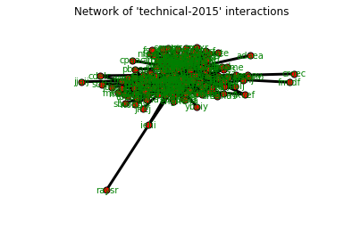

```python
import networkx as nx

# Network creation without direction
G_Technical2015_top500 = nx.Graph()

# Here we just create links between senders and addressees and the
# 'weight' of add_edge function is the value of the number of interaction.
for i in range(len(df_tech2015_concat)):
    G_Technical2015_top500.add_edge(df_tech2015_concat["Interlocutor_1"][i],
                                    df_tech2015_concat["Interlocutor_2"][i],
                                    weight = df_tech2015_concat["Interactions"][i])

# Automatic generator of nodes position.
pos = nx.spring_layout(G_Technical2015_top500)

# Node creation
nx.draw_networkx_nodes(G_Technical2015_top500, pos, node_size=50)

# Links creation
nx.draw_networkx_edges(G_Technical2015_top500, pos, width=3, edge_color='black')

# Display nodes labels (names)
nx.draw_networkx_labels(G_Technical2015_top500, pos, font_size=10, font_family='sans-serif', font_color="green")

# Display and save network
plt.axis('off')
plt.title("Network of 'technical-2015' interactions")
plt.savefig("description_nb/networkx_generated/Top500_technical_2015")
plt.show()
```

```python
# Not really pretty isn't it ?!
# Let's look at Gephi power !!
nx.write_gexf(G_Technical2015_top500, "description_nb/networkx_generated/Top500_technical_2015.gexf")

#Hop hop hop, before that, a little automation !
```

```python
from pypletics import get_my_network

# Look at the package we created !
help(get_my_network)
```

```
Help on function get_my_network in module pypletics.network:

get_my_network(df_target, sender_column, addressee_column, graph_name, generate_png=False, generate_gexf=False, top_n=None)
    'get_my_network' function from pyple package take as parameters a dataframe with 2 columns representing an exchange like sender-addressee.
    The second parameter will be the name of the first column, the third parameter will be the name of the second column.
    Using the fourth parameter you will give a name to your network as a file and as a plot graphic too.
    You can choose with the 5th and the 6th parameters to save the result as .png ou .gexf.
    If you don't specified these arguments, they won't be generated by default.
    The last parameter is optional and allow us to choose the number of the best interactions you want to work with.
    Without the 'top_n' argument, the function will work with the all interactions of your dataframe.
    Once this function will be executed, an array will be return with:
    - index 0: your dataframe concatenated
    - index 1: a python plot of your network
    - index 2: the final Graph value
```

```python
# Let's do the same job we did before but with the 2016 network
df_tech2016_concat = df_visualization[(df_visualization.Prediction == 1)
                                      & (df_visualization.Year == "2016")].copy()
print("df_tech2016_concat size:", len(df_tech2016_concat))
```

```
df_tech2016_concat size: 101088
```

```python
technical_network = get_my_network(df_tech2016_concat, df_tech2016_concat.Sender, df_tech2016_concat.Addressee,
                                   "description_nb/networkx_generated/Top500_technical_2016",
                                   generate_gexf = True, top_n = 500)

technical_network[0].head()
```

|  | Interlocutor_1 | Interlocutor_2 | Interactions |
| --- | --- | --- | --- |
| 0 | afaea | pfasp | 490 |
| 1 | aesla | afaea | 464 |
| 2 | afaea | sbrds | 400 |
| 3 | agrsa | mboym | 380 |
| 4 | btohb | mboym | 364 |

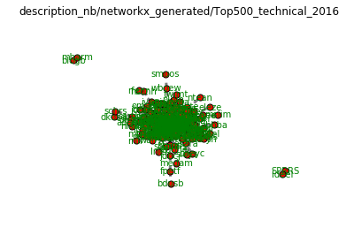

```python
print(type(technical_network[2]), '\n')
technical_network[1].show()
```

• And this is the kind of results we can obtain using Gephi ! -> technical-2016.  
Sub clusters colored are obtained with a modularity algorithm based on weight (interactions number) using Gephi.  
Knowing node names, it's up to you to interpret if sub cluster represents Big Data, Architecture or Devops department for example.

[figure not shown]

MERCI !! THANK YOU !!  
OCTO Technology - Clément Tailleur